# **Analysis of Categorical Data - Phase 1**

**Project Group Name :** Project Groups 77  
**Members :**

- **Shubham Gupta** - **s3806186**

## **Plausible causes of Heart Disease (UCI Analysis of Heart Disease)**

#### **Table of content :**

- Data Source and Description Describes our `hearts.csv` dataset and its features.
- Goals and Objectives Our reason for selecting this dataset and what our goal is.
- Data Cleaning and Preprocessing Process for Data cleaning and Data Transformation.
- Data Exploration and Visualization Identifying and plotting Uni,Bi and Multi variate relationships between the features in our dataset.
- Preparing Data For Modeling Encoding categorical features in order to prepare data for modeling
- References Sources we refered for our project

### **Data Source and Description**

*Source* : Heart Disease UCI. Kaggle.com. (2020). Retrieved 24 September 2020, from https://www.kaggle.com/ronitf/heart-disease-uci.

##### **Overview of the Dataset** : Our datasouce is sourced from the oringinal databases of Cleveland, Hungaria, Switzerland and Long Beach VA, concerning heart disease diagnosis.The original database consisted of a total of 76 raw attributes, however for the purpose of modeling the data, only 14 of them were actually used.Our dataset deals in identifying the various factors that might lead to the diagnosis of a Heart disease.

##### **Description of the Dataset** : The `hearts.csv` dataset contains a total of 303 observations, taken from the instances of the Cleveland database and has a total of 14 features out of which 13 are descriptive features and `target` is our target feature.

The following is the detailed description of the features in the dataset.

[output not shown]

**Target feature :** The feature `target` in our dataset is our target feature with two possible categories :  
**0** : No heart disease and  
**1** : Heart disease.  
In order for a person to be diagosed with a heart disease, there has to be greater than 50% narrowing of any major vessel.

### **Goals and Objectives**

The importance of machine learning and statistical modeling in the field of healthcare is unparallel when compared to any other field as it ultimately deals with the matter of a person's health and well being. However, in order to fully utilize the advantages of statistical modeling, careful statistical and insightful analysis of data must be performed. With the availability of more and more public healthcare data the need to identify possible trends or patterns in order to identify or prevent diseases has become the need of the hour.

Our dataset deals with the person having a heart disease or not based on various attributes and features.

Our aim is to identify which feature or set of features recorded during a patient's diagnosis plays an important role in determining whether a person is more likely to have a heart disease or not.

### **Data Cleaning and Preprocessing**

##### **Importing Libraries**

```python
import pandas as pd
import numpy as np
import matplotlib.pyplot as plt
import seaborn as sns
import warnings
```

##### **Settings**

```python
warnings.filterwarnings("ignore")
pd.set_option('display.max_columns', None)
```

##### **Importing the dataset**

##### Using the `pd.read_csv()` method to read the dataset

```python
df=pd.read_csv('./Project_Groups_77_Data.csv')
# Displaying the first five rows of the dataset
df.head()
```

|  | age | sex | cp | trestbps | chol | fbs | restecg | thalach | exang | oldpeak | slope | ca | thal | target |
| --- | --- | --- | --- | --- | --- | --- | --- | --- | --- | --- | --- | --- | --- | --- |
| 0 | 63 | 1 | 3 | 145 | 233 | 1 | 0 | 150 | 0 | 2.3 | 0 | 0 | 1 | 1 |
| 1 | 37 | 1 | 2 | 130 | 250 | 0 | 1 | 187 | 0 | 3.5 | 0 | 0 | 2 | 1 |
| 2 | 41 | 0 | 1 | 130 | 204 | 0 | 0 | 172 | 0 | 1.4 | 2 | 0 | 2 | 1 |
| 3 | 56 | 1 | 1 | 120 | 236 | 0 | 1 | 178 | 0 | 0.8 | 2 | 0 | 2 | 1 |
| 4 | 57 | 0 | 0 | 120 | 354 | 0 | 1 | 163 | 1 | 0.6 | 2 | 0 | 2 | 1 |

##### **Data Cleaning and Preparation**

```python
# Displaying the dimension of the dataset
df.shape
```

```
(303, 14)
```

```python
# Getting an overview of the data types of all columns in the dataframe
df.dtypes
```

```
age           int64
sex           int64
cp            int64
trestbps      int64
chol          int64
fbs           int64
restecg       int64
thalach       int64
exang         int64
oldpeak     float64
slope         int64
ca            int64
thal          int64
target        int64
dtype: object
```

Checking for columns which are constant i.e. having only one unique value using the `nunique()` method

```python
for cols in df.columns:
  print("Column Name : ",cols)
  print("Unique Values : ",df[cols].nunique())
```

```
Column Name :  age
Unique Values :  41
Column Name :  sex
Unique Values :  2
Column Name :  cp
Unique Values :  4
Column Name :  trestbps
Unique Values :  49
Column Name :  chol
Unique Values :  152
Column Name :  fbs
Unique Values :  2
Column Name :  restecg
Unique Values :  3
Column Name :  thalach
Unique Values :  91
Column Name :  exang
Unique Values :  2
Column Name :  oldpeak
Unique Values :  40
Column Name :  slope
Unique Values :  3
Column Name :  ca
Unique Values :  5
Column Name :  thal
Unique Values :  4
Column Name :  target
Unique Values :  2
```

From the above output we can clearly conclude that the dataset has no constant features.

##### **Handling Missing Values**

Looping through all the columns to find if there are any missing values in the dataset using the `isnull().sum()` method.

```python
for cols in df.columns:
  print("Column Name : ",cols)
  print("Missing Values : ",df[cols].isnull().sum())
```

```
Column Name :  age
Missing Values :  0
Column Name :  sex
Missing Values :  0
Column Name :  cp
Missing Values :  0
Column Name :  trestbps
Missing Values :  0
Column Name :  chol
Missing Values :  0
Column Name :  fbs
Missing Values :  0
Column Name :  restecg
Missing Values :  0
Column Name :  thalach
Missing Values :  0
Column Name :  exang
Missing Values :  0
Column Name :  oldpeak
Missing Values :  0
Column Name :  slope
Missing Values :  0
Column Name :  ca
Missing Values :  0
Column Name :  thal
Missing Values :  0
Column Name :  target
Missing Values :  0
```

##### **Converting columns to `object` datatype from `int64` or `float64` datatypes.**

Since, a number of columns in the dataset are wronlgly classified as numeric features instead of categorical features, we need to convert them to categorical datatype.

```python
# Generating lists of categorical and numerical columns
categorical_columns=['sex','cp','fbs','restecg','exang','slope','thal','target']
numerical_columns=['age','trestbps','chol','thalach','oldpeak','ca']
```

Converting the possible categorical columns using the `astype('object')` method.

```python
for cols in categorical_columns:
  df[cols]=df[cols].astype('object')

# Checking the datatypes of all the columns again
df.dtypes
```

```
age           int64
sex          object
cp           object
trestbps      int64
chol          int64
fbs          object
restecg      object
thalach       int64
exang        object
oldpeak     float64
slope        object
ca            int64
thal         object
target       object
dtype: object
```

##### **Checking for possible typos,impossible values, etc using the `.unique()` method for all features.**

```python
 for col in df:
  print("Column : ",col)
  print(df[col].unique())
```

```
Column :  age
[63 37 41 56 57 44 52 54 48 49 64 58 50 66 43 69 59 42 61 40 71 51 65 53
 46 45 39 47 62 34 35 29 55 60 67 68 74 76 70 38 77]
Column :  sex
[1 0]
Column :  cp
[3 2 1 0]
Column :  trestbps
[145 130 120 140 172 150 110 135 160 105 125 142 155 104 138 128 108 134
 122 115 118 100 124  94 112 102 152 101 132 148 178 129 180 136 126 106
 156 170 146 117 200 165 174 192 144 123 154 114 164]
Column :  chol
[233 250 204 236 354 192 294 263 199 168 239 275 266 211 283 219 340 226
 247 234 243 302 212 175 417 197 198 177 273 213 304 232 269 360 308 245
 208 264 321 325 235 257 216 256 231 141 252 201 222 260 182 303 265 309
 186 203 183 220 209 258 227 261 221 205 240 318 298 564 277 214 248 255
 207 223 288 160 394 315 246 244 270 195 196 254 126 313 262 215 193 271
 268 267 210 295 306 178 242 180 228 149 278 253 342 157 286 229 284 224
 206 167 230 335 276 353 225 330 290 172 305 188 282 185 326 274 164 307
 249 341 407 217 174 281 289 322 299 300 293 184 409 259 200 327 237 218
 319 166 311 169 187 176 241 131]
Column :  fbs
[1 0]
Column :  restecg
[0 1 2]
Column :  thalach
[150 187 172 178 163 148 153 173 162 174 160 139 171 144 158 114 151 161
 179 137 157 123 152 168 140 188 125 170 165 142 180 143 182 156 115 149
 146 175 186 185 159 130 190 132 147 154 202 166 164 184 122 169 138 111
 145 194 131 133 155 167 192 121  96 126 105 181 116 108 129 120 112 128
 109 113  99 177 141 136  97 127 103 124  88 195 106  95 117  71 118 134
  90]
Column :  exang
[0 1]
Column :  oldpeak
[2.3 3.5 1.4 0.8 0.6 0.4 1.3 0.  0.5 1.6 1.2 0.2 1.8 1.  2.6 1.5 3.  2.4
 0.1 1.9 4.2 1.1 2.  0.7 0.3 0.9 3.6 3.1 3.2 2.5 2.2 2.8 3.4 6.2 4.  5.6
 2.9 2.1 3.8 4.4]
Column :  slope
[0 2 1]
Column :  ca
[0 2 1 3 4]
Column :  thal
[1 2 3 0]
Column :  target
[1 0]
```

##### **Summary Statistics for Continuous Features**

```python
df.describe(exclude='object')
```

|  | age | trestbps | chol | thalach | oldpeak | ca |
| --- | --- | --- | --- | --- | --- | --- |
| count | 303.000000 | 303.000000 | 303.000000 | 303.000000 | 303.000000 | 303.000000 |
| mean | 54.366337 | 131.623762 | 246.264026 | 149.646865 | 1.039604 | 0.729373 |
| std | 9.082101 | 17.538143 | 51.830751 | 22.905161 | 1.161075 | 1.022606 |
| min | 29.000000 | 94.000000 | 126.000000 | 71.000000 | 0.000000 | 0.000000 |
| 25% | 47.500000 | 120.000000 | 211.000000 | 133.500000 | 0.000000 | 0.000000 |
| 50% | 55.000000 | 130.000000 | 240.000000 | 153.000000 | 0.800000 | 0.000000 |
| 75% | 61.000000 | 140.000000 | 274.500000 | 166.000000 | 1.600000 | 1.000000 |
| max | 77.000000 | 200.000000 | 564.000000 | 202.000000 | 6.200000 | 4.000000 |

##### **Summary Statistics for Categorical Features**

```python
df.describe(include='object')
```

|  | sex | cp | fbs | restecg | exang | slope | thal | target |
| --- | --- | --- | --- | --- | --- | --- | --- | --- |
| count | 303 | 303 | 303 | 303 | 303 | 303 | 303 | 303 |
| unique | 2 | 4 | 2 | 3 | 2 | 3 | 4 | 2 |
| top | 1 | 0 | 0 | 1 | 0 | 2 | 2 | 1 |
| freq | 207 | 143 | 258 | 152 | 204 | 142 | 166 | 165 |

### **Data Exploration and Visualization**

##### **Uni-Variate Plots and Analysis**

##### **1. Bar chart for `sex` column.**

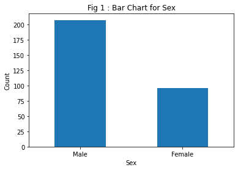

```python
# 1. Bar chart for 'sex' column
ax = df['sex'].map({0:'Female',1:'Male'}).value_counts().plot(kind='bar',rot=0)
ax.set_xlabel('Sex')
ax.set_ylabel('Count')
ax.set_title('Fig 1 : Bar Chart for Sex')
```

**Explanation :**From the above bar chart we can see that there are significant more males as compared to females in our dataset.

##### **2. Bar chart for `fbs` column.**

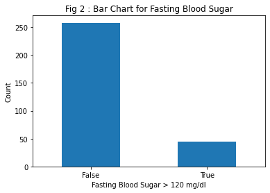

```python
# 2. Bar chart for 'fbs' column
ax = df['fbs'].map({0:'False',1:'True'}).value_counts().plot(kind='bar',rot=0)
ax.set_xlabel('Fasting Blood Sugar > 120 mg/dl')
ax.set_ylabel('Count')
ax.set_title('Fig 2 : Bar Chart for Fasting Blood Sugar')
```

**Explanation :** From the above bar graph we can conclude for majority of the observations the fasting blood sugar level is less than 120 mg/dl.

##### **3. Bar chart for `exang` column.**

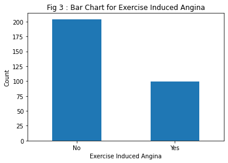

```python
# 3. Bar chart for 'exang' column
ax = df['exang'].map({0:'No',1:'Yes'}).value_counts().plot(kind='bar',rot=0)
ax.set_xlabel('Exercise Induced Angina')
ax.set_ylabel('Count')
ax.set_title('Fig 3 : Bar Chart for Exercise Induced Angina')
```

**Explanation :** From the above bar graph we can conclude that the count of people with exercise induced angina is comparatively lower than people which were induced with angina through exercise.

##### **4. Boxplot for `age` column.**

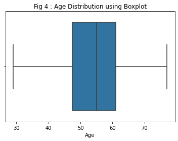

```python
# 4. Boxplot for `age` column
ax=sns.boxplot(x=df['age'])
ax.set_title("Fig 4 : Age Distribution using Boxplot")
ax.set_xlabel('Age')
```

**Explanation :** From the above box plot we can see that most of the people are between their late 40s and early 60s.

##### **Bi-Variate Plots and Analysis**

##### **5. Bar chart for `exang` vs `target` columns.**

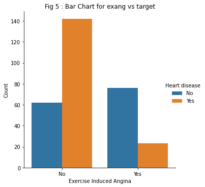

```python
# 5. Bar chart for `exang` vs `target` columns.
df_exang = df[['target', 'exang']].copy()
df_exang_agg = df_exang.groupby(['target', 'exang']).size().reset_index(name='counts')
df_exang_agg['exang'] = df_exang_agg['exang'].map({0:"No", 1:"Yes"})
df_exang_agg['target'] = df_exang_agg['target'].map({0:"No", 1:"Yes"})
ax = sns.factorplot(x='exang', y='counts', hue='target', data=df_exang_agg, kind='bar')
ax.set(xlabel='Exercise Induced Angina', ylabel='Count')
ax._legend.set_title("Heart disease")
plt.title("Fig 5 : Bar Chart for exang vs target")
plt.show()
```

##### **6. Boxplot for `target` vs `oldpeak` columns.**

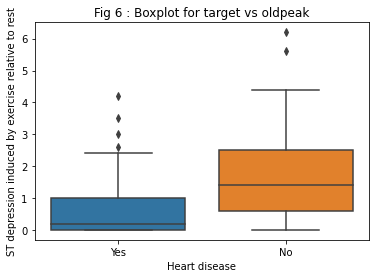

```python
# 6. Boxplot for `target` vs `oldpeak` columns.**
df_oldpeak = df[['target','oldpeak']]
df_oldpeak['target'] = df_oldpeak['target'].map({0:"No", 1:"Yes"})
ax = sns.boxplot(data = df_oldpeak, x = 'target', y = 'oldpeak')
ax.set(xlabel = 'Heart disease', ylabel='ST depression induced by exercise relative to rest')
plt.title("Fig 6 : Boxplot for target vs oldpeak")
plt.show()
```

**Explanation :** From the above box plot we can see that people with higher ST depression induced by exercise relative to rest are at a lower risk of having a heart condition comparatively.

##### **7. Boxplot for `target` vs `chol` columns.**

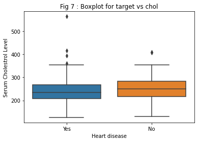

```python
# 7. Boxplot for `target` vs `chol` columns
df_chol = df[['target','chol']]
df_chol['target'] = df_chol['target'].map({0:"No", 1:"Yes"})
ax = sns.boxplot(data = df_chol, x = 'target', y = 'chol')
ax.set(xlabel = 'Heart disease', ylabel='Serum Cholestrol Level')
plt.title("Fig 7 : Boxplot for target vs chol")
plt.show()
```

**Explanation :** From the above box plot we can see that for a person having lower serum cholestoral level is more likely to have a heart disease as compared to a person who has a higher level of serum cholestoral.

##### **8. Correlation matrix for numeric features**

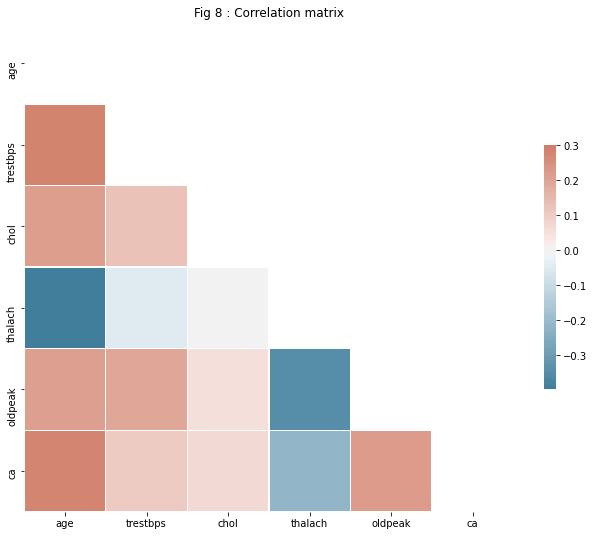

```python
# 8. Generating correlation matrix
corr = df.corr()
mask = np.triu(np.ones_like(corr, dtype=bool))
f, ax = plt.subplots(figsize=(11, 9))
cmap = sns.diverging_palette(230, 20, as_cmap=True)
sns.heatmap(corr, mask=mask, cmap=cmap, vmax=.3, center=0,
            square=True, linewidths=.5, cbar_kws={"shrink": .5})
plt.title("Fig 8 : Correlation matrix")
```

##### **Multi-Variate Plots and Analysis**

##### **9. Scatter plot for `age` vs `oldpeak` vs `target` columns.**

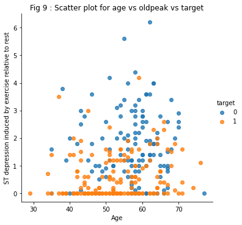

```python
# 9. Scatter plot for `age` vs `oldpeak` vs `target` columns
ax=sns.lmplot(x='age', y='oldpeak', hue='target',data=df,fit_reg=False)
ax.set(xlabel = 'Age', ylabel='ST depression induced by exercise relative to rest')
plt.title("Fig 9 : Scatter plot for age vs oldpeak vs target")
plt.show()
```

**Explanation :** From the above Scatter plot we can see that irrespective of the age of the person ,for majority of low values for ST depression induced through exercise, most of them are likely to have an heart disease.

##### **10. Boxplot for `sex` vs `trestbps` vs `target` columns.**

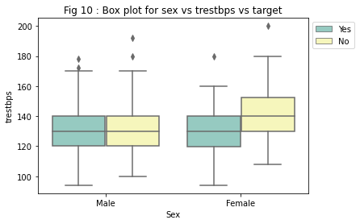

```python
# 10. Boxplot for `sex` vs `trestbps` vs `target` columns
df_sex_trestbps = df[['target','sex','trestbps']]
df_sex_trestbps['target'] = df_sex_trestbps['target'].map({0:"No", 1:"Yes"})
df_sex_trestbps['sex'] = df_sex_trestbps['sex'].map({0:"Female", 1:"Male"})
ax = sns.boxplot(x='sex', y='trestbps', hue="target",data=df_sex_trestbps, palette="Set3")
ax.legend(loc='best',bbox_to_anchor=(1.0, 1.0));
ax.set(xlabel = 'Sex', ylabel='trestbps')
plt.title("Fig 10 : Box plot for sex vs trestbps vs target")
plt.show()
```

**Explanation :** From the above Boxplot we can see that for males irrespective of whether they are diagnosed with heart disease or not, the resting blood pressure at the time of admission to the hospital is approximately the same,whereas, for females the median value for females diagnosed with heart disease is lower as compared to females not diagnosed with heart disease.

##### **11. Boxplot for `sex` vs `chol` vs `target` columns.**

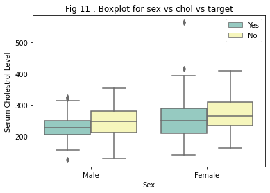

```python
# 11. Boxplot for `sex` vs `chol` vs `target` columns
df_sex_chol = df[['target','sex','chol']]
df_sex_chol['target'] = df_sex_chol['target'].map({0:"No", 1:"Yes"})
df_sex_chol['sex'] = df_sex_chol['sex'].map({0:"Female", 1:"Male"})
ax = sns.boxplot(x='sex', y='chol', hue="target",data=df_sex_chol, palette="Set3")
ax.legend(loc='best',bbox_to_anchor=(1.0, 1.0));
ax.set(xlabel = 'Sex', ylabel='Serum Cholestrol Level')
plt.title("Fig 11 : Boxplot for sex vs chol vs target")
plt.show()
```

**Explanation :** From the above Boxplot we can see that irrespective of the gender of the person,if the person is diagnosed with an heart disease the serum cholestoral level is lower as compared to a person who is not diagnosed with an heart disease.

### **Preparing data for modeling**

Encoding the target feature:

```python
df_encoded = df.drop(columns='target')
target = df['target']
target.value_counts()
```

```
1    165
0    138
Name: target, dtype: int64
```

```python
target = target.replace({'0': 0, '1': 1})
target.value_counts()
```

```
1    165
0    138
Name: target, dtype: int64
```

Encoding descriptive features:

```python
categorical_cols = df_encoded.columns[df_encoded.dtypes==object].tolist()
categorical_cols
```

```
['sex', 'cp', 'fbs', 'restecg', 'exang', 'slope', 'thal']
```

```python
for col in categorical_cols:
    n = len(df_encoded[col].unique())
    if (n == 2):
        df_encoded[col] = pd.get_dummies(df_encoded[col], drop_first=True)

# One-hot-encoding for categorical features with more than two levels
df_encoded = pd.get_dummies(df_encoded)
```

```python
df_encoded.columns
```

```
Index(['age', 'sex', 'trestbps', 'chol', 'fbs', 'thalach', 'exang', 'oldpeak',
       'ca', 'cp_0', 'cp_1', 'cp_2', 'cp_3', 'restecg_0', 'restecg_1',
       'restecg_2', 'slope_0', 'slope_1', 'slope_2', 'thal_0', 'thal_1',
       'thal_2', 'thal_3'],
      dtype='object')
```

Final dataframe after encoding:

```python
df_encoded['target'] = target
df_encoded.head()
```

|  | age | sex | trestbps | chol | fbs | thalach | exang | oldpeak | ca | cp_0 | cp_1 | cp_2 | cp_3 | restecg_0 | restecg_1 | restecg_2 | slope_0 | slope_1 | slope_2 | thal_0 | thal_1 | thal_2 | thal_3 | target |
| --- | --- | --- | --- | --- | --- | --- | --- | --- | --- | --- | --- | --- | --- | --- | --- | --- | --- | --- | --- | --- | --- | --- | --- | --- |
| 0 | 63 | 1 | 145 | 233 | 1 | 150 | 0 | 2.3 | 0 | 0 | 0 | 0 | 1 | 1 | 0 | 0 | 1 | 0 | 0 | 0 | 1 | 0 | 0 | 1 |
| 1 | 37 | 1 | 130 | 250 | 0 | 187 | 0 | 3.5 | 0 | 0 | 0 | 1 | 0 | 0 | 1 | 0 | 1 | 0 | 0 | 0 | 0 | 1 | 0 | 1 |
| 2 | 41 | 0 | 130 | 204 | 0 | 172 | 0 | 1.4 | 0 | 0 | 1 | 0 | 0 | 1 | 0 | 0 | 0 | 0 | 1 | 0 | 0 | 1 | 0 | 1 |
| 3 | 56 | 1 | 120 | 236 | 0 | 178 | 0 | 0.8 | 0 | 0 | 1 | 0 | 0 | 0 | 1 | 0 | 0 | 0 | 1 | 0 | 0 | 1 | 0 | 1 |
| 4 | 57 | 0 | 120 | 354 | 0 | 163 | 1 | 0.6 | 0 | 1 | 0 | 0 | 0 | 0 | 1 | 0 | 0 | 0 | 1 | 0 | 0 | 1 | 0 | 1 |

### **References**

- Heart Disease UCI. Kaggle.com. (2020). Retrieved 24 September 2020, from https://www.kaggle.com/ronitf/heart-disease-uci.
- www.featureranking.com. 2020. Regression Case Study | Www.Featureranking.Com. [online] Available at: https://www.featureranking.com/tutorials/statistics-tutorials/regression-case-study/ [Accessed 25 September 2020].
- www.featureranking.com. 2020. Regression Case Study | Www.Featureranking.Com. [online] Available at: https://www.featureranking.com/tutorials/machine-learning-tutorials/case-study-predicting-income-status/ [Accessed 25 September 2020].